# Report 10

Advay Vyas

November 06, 2025

# Introduction

This week, I will be looking at the best combination of parameters for BART, looking at other metrics that explain more about the models instead of just coverage rate, trying this new vaccine data, and testing XGBoost in our current setup.

# Data preprocessing

```r
df_complete = read.csv("../complete_metrics.csv")
df_complete = drop_na(df_complete)

set.seed(777)
n = nrow(df_complete)
train_idx = sample(seq_len(n), size = floor(0.8 * n))  # 80% train
test_idx = setdiff(seq_len(n), train_idx)

vars = c("pop_ratio", "pct_urban", "density_ratio", "n_hsa",
    "area_ratio", "education_diff", "income_diff", "poverty_diff",
    "unemployment_diff")

x.train = df_complete[train_idx, vars]
y.train = df_complete$diff_wis_season[train_idx]

x.test = df_complete[test_idx, vars]
y.test = df_complete$diff_wis_season[test_idx]
```

# Best parameters for BART

```r
param_grid = expand.grid(ntree = c(100, 200, 300), k = c(1, 1.5,
    2), power = c(1.5, 2, 2.5), base = c(0.9, 0.95, 0.99))

K = 5
folds = sample(rep(1:K, length.out = nrow(x.train)))
coverage_prob = 0.95

cv_metrics = function(params) {
    rmse_vec = r2_vec = adjr2_vec = cov_vec = numeric(K)

    for (fold in 1:K) {
        train_idx = which(folds != fold)
        test_idx = which(folds == fold)

        x_tr = x.train[train_idx, ]
        y_tr = y.train[train_idx]
        x_te = x.train[test_idx, ]
        y_te = y.train[test_idx]

        fit = bart(x.train = x_tr, y.train = y_tr, x.test = x_te,
            ntree = params$ntree, k = params$k, power = params$power,
            base = params$base, verbose = FALSE)

        pred_mean = fit$yhat.test.mean
        pred_ci = apply(fit$yhat.test, 2, quantile, probs = c((1 -
            coverage_prob)/2, 1 - (1 - coverage_prob)/2))
        ci_low = pred_ci[1, ]
        ci_high = pred_ci[2, ]

        rmse = sqrt(mean((y_te - pred_mean)^2))
        r2 = 1 - sum((y_te - pred_mean)^2)/sum((y_te - mean(y_te))^2)
        p = ncol(x_tr)
        n = length(y_te)
        adjr2 = 1 - (1 - r2) * (n - 1)/(n - p - 1)
        coverage = mean(y_te >= ci_low & y_te <= ci_high)

        rmse_vec[fold] = rmse
        r2_vec[fold] = r2
        adjr2_vec[fold] = adjr2
        cov_vec[fold] = coverage
    }

    tibble(rmse = mean(rmse_vec), r2 = mean(r2_vec), adjr2 = mean(adjr2_vec),
        coverage = mean(cov_vec))
}

results = param_grid %>%
    rowwise() %>%
    mutate(metrics = list(cv_metrics(cur_data_all()))) %>%
    unnest_wider(metrics)
```

```r
head(results %>%
    arrange(desc(coverage)), n = 8L)
```

```
## # A tibble: 8 × 8
##   ntree     k power  base  rmse     r2  adjr2 coverage
##   <dbl> <dbl> <dbl> <dbl> <dbl>  <dbl>  <dbl>    <dbl>
## 1   300     1   1.5  0.99 0.238 0.0676 -0.412    0.839
## 2   300     1   2    0.9  0.231 0.141  -0.300    0.832
## 3   200     1   1.5  0.95 0.236 0.0952 -0.369    0.832
## 4   300     1   1.5  0.95 0.236 0.0902 -0.378    0.832
## 5   200     1   1.5  0.99 0.238 0.0831 -0.388    0.832
## 6   300     1   2    0.99 0.236 0.0973 -0.367    0.832
## 7   200     1   1.5  0.9  0.231 0.142  -0.299    0.825
## 8   100     1   2    0.99 0.228 0.179  -0.242    0.825
```

```r
results[which.max(results$r2), ]
```

```
## # A tibble: 1 × 8
##   ntree     k power  base  rmse    r2   adjr2 coverage
##   <dbl> <dbl> <dbl> <dbl> <dbl> <dbl>   <dbl>    <dbl>
## 1   100     2   2.5   0.9 0.215 0.290 -0.0744    0.680
```

```r
results[which.max(results$coverage), ]
```

```
## # A tibble: 1 × 8
##   ntree     k power  base  rmse     r2  adjr2 coverage
##   <dbl> <dbl> <dbl> <dbl> <dbl>  <dbl>  <dbl>    <dbl>
## 1   300     1   1.5  0.99 0.238 0.0676 -0.412    0.839
```

```r
results[which.max(results$rmse), ]
```

```
## # A tibble: 1 × 8
##   ntree     k power  base  rmse     r2  adjr2 coverage
##   <dbl> <dbl> <dbl> <dbl> <dbl>  <dbl>  <dbl>    <dbl>
## 1   300     1     2  0.95 0.239 0.0742 -0.402    0.817
```

Basically, the model can give good intervals a lot of the time but can’t explain the small variations in HSA differences along the testing data set. Probably just something to do with how this model (which uses some form of MCMC I think) works since one of it’s main goals is in-built confidence intervals.

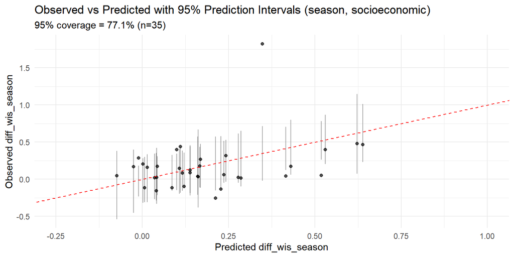

```r
bart_fit = bart(x.train = x.train, y.train = y.train, verbose = FALSE,
    keeptrees = TRUE, k = 1, base = 0.99, power = 1.5, ntree = 300)

pred = predict(bart_fit, newdata = x.test)
bart_predictions = as.data.frame(t(apply(pred, 2, quantile, probs = c(0.025,
    0.975))))
colnames(bart_predictions) = c("ci_low", "ci_high")

bart_predictions$estimate = apply(pred, 2, mean)
bart_predictions$observed = y.test

coverage_95_bart = mean(bart_predictions$observed >= bart_predictions$ci_low &
    bart_predictions$observed <= bart_predictions$ci_high, na.rm = TRUE)

ggplot(bart_predictions, aes(x = estimate, y = observed)) + geom_errorbar(aes(ymin = ci_low,
    ymax = ci_high), width = 0, alpha = 0.35) + geom_point(alpha = 0.7) +
    geom_abline(slope = 1, intercept = 0, linetype = "dashed",
        color = "red") + labs(x = "Predicted diff_wis_season",
    y = "Observed diff_wis_season", title = "Observed vs Predicted with 95% Prediction Intervals (season, socioeconomic)",
    subtitle = sprintf("95%% coverage = %.1f%% (n=%d)", 100 *
        coverage_95_bart, nrow(bart_predictions))) + theme_minimal() +
    scale_x_continuous(breaks = seq(-1, 2, by = 0.25)) + coord_cartesian(xlim = c(-0.25,
    1))
```

# Vaccine data

```r
vaccine = read.csv("flu_vaccine_coverage.csv") %>%
    filter(Geography.Type == "Counties", Season.Survey.Year ==
        "2022") %>%
    select(Geography, FIPS, Estimate...., X95..CI....)

colnames(vaccine) = c("Geography", "GEOID", "vaccine_estimate",
    "CI")
vaccine = vaccine %>%
    separate(CI, into = c("lowCI", "highCI"), sep = " to ")

vaccine$vaccine_estimate = as.numeric(vaccine$vaccine_estimate)

vaccine_unique = vaccine %>%
    group_by(GEOID) %>%
    summarise(across(where(is.numeric), \(x) mean(x,
        na.rm = TRUE)))
```

```r
df_complete = read.csv("../complete_metrics.csv")
df_complete = drop_na(df_complete)

df_complete = left_join(df_complete, vaccine[, 2:3], by = "GEOID")
table(is.na(df_complete$vaccine_estimate))
```

```
##
## FALSE  TRUE
##    57   116
```

```r
df_complete = drop_na(df_complete)
```

We’re dropping the NAs to see if it has any effect, this becomes a very small dataset though.

```r
set.seed(777)
n = nrow(df_complete)
train_idx = sample(seq_len(n), size = floor(0.4 * n))  # 40% train
test_idx = setdiff(seq_len(n), train_idx)

vax_vars = c("pop_ratio", "pct_urban", "density_ratio", "n_hsa",
    "area_ratio", "education_diff", "income_diff", "poverty_diff",
    "unemployment_diff", "vaccine_estimate")

x.train_vax = df_complete[train_idx, vax_vars]
y.train_vax = df_complete$diff_wis_season[train_idx]

x.test_vax = df_complete[test_idx, vax_vars]
y.test_vax = df_complete$diff_wis_season[test_idx]
```

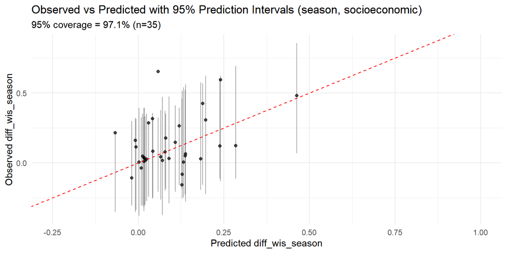

```r
bart_fit_vax = bart(x.train = x.train_vax, y.train = y.train_vax,
    verbose = FALSE, keeptrees = TRUE)

pred_vax = predict(bart_fit_vax, newdata = x.test_vax)
bart_predictions_vax = as.data.frame(t(apply(pred_vax, 2, quantile,
    probs = c(0.025, 0.975))))
colnames(bart_predictions_vax) = c("ci_low", "ci_high")

bart_predictions_vax$estimate = apply(pred_vax, 2, mean)
bart_predictions_vax$observed = y.test_vax

coverage_95_bart_vax = mean(bart_predictions_vax$observed >=
    bart_predictions_vax$ci_low & bart_predictions_vax$observed <=
    bart_predictions_vax$ci_high, na.rm = TRUE)

ggplot(bart_predictions_vax, aes(x = estimate, y = observed)) +
    geom_errorbar(aes(ymin = ci_low, ymax = ci_high), width = 0,
        alpha = 0.35) + geom_point(alpha = 0.7) + geom_abline(slope = 1,
    intercept = 0, linetype = "dashed", color = "red") + labs(x = "Predicted diff_wis_season",
    y = "Observed diff_wis_season", title = "Observed vs Predicted with 95% Prediction Intervals (season, socioeconomic)",
    subtitle = sprintf("95%% coverage = %.1f%% (n=%d)", 100 *
        coverage_95_bart_vax, nrow(bart_predictions_vax))) +
    theme_minimal() + scale_x_continuous(breaks = seq(-1, 2,
    by = 0.25)) + coord_cartesian(xlim = c(-0.25, 1))
```

These intervals are insanely wide it is actually crazy. Also, shouldn’t these lines actually be horizontal because they are the width of the prediction intervals? Not sure though. Looks like it helps but results are on a small sample size but there is a low train/test split, 40 percent train only.

# XGBoost implementation

```r
dtrain = xgb.DMatrix(data = as.matrix(x.train), label = y.train)
dtest = xgb.DMatrix(data = as.matrix(x.test), label = y.test)

params = list(objective = "reg:squarederror", eval_metric = "rmse",
    eta = 0.1, max_depth = 6, subsample = 0.8, colsample_bytree = 0.8)

set.seed(123)
xgb_fit = xgb.train(params = params, data = dtrain, nrounds = 300,
    watchlist = list(train = dtrain, test = dtest), verbose = 0)

pred_mean = predict(xgb_fit, as.matrix(x.test))

n = length(y.test)
p = ncol(x.train)
R2 = 1 - sum((y.test - pred_mean)^2)/sum((y.test - mean(y.test))^2)
adj_R2 = 1 - (1 - R2) * (n - 1)/(n - p - 1)
RMSE = sqrt(mean((y.test - pred_mean)^2))

cat(sprintf("R² = %.3f, Adjusted R² = %.3f, RMSE = %.3f\n",
    R2, adj_R2, RMSE))
```

```
## R² = -0.039, Adjusted R² = -0.413, RMSE = 0.343
```

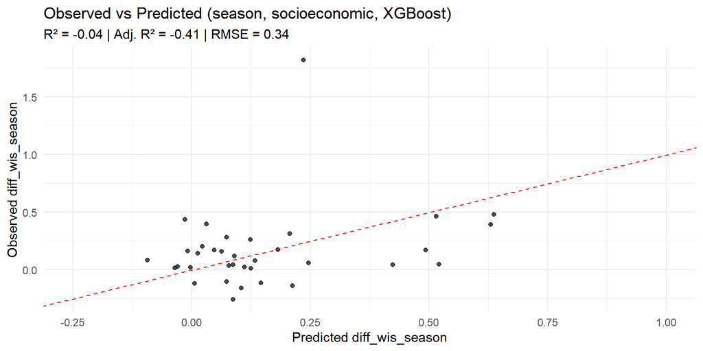

```r
xgb_predictions = data.frame(estimate = pred_mean, observed = y.test)

ggplot(xgb_predictions, aes(x = estimate, y = observed)) + geom_point(alpha = 0.7) +
    geom_abline(slope = 1, intercept = 0, linetype = "dashed",
        color = "red") + labs(x = "Predicted diff_wis_season",
    y = "Observed diff_wis_season", title = "Observed vs Predicted (season, socioeconomic, XGBoost)",
    subtitle = sprintf("R² = %.2f | Adj. R² = %.2f | RMSE = %.2f",
        R2, adj_R2, RMSE)) + theme_minimal() + scale_x_continuous(breaks = seq(-1,
    2, by = 0.25)) + coord_cartesian(xlim = c(-0.25, 1))
```

Okay, now we try with confidence intervals.

```r
set.seed(123)
B = 50
pred_matrix = replicate(B, {
    params$subsample = runif(1, 0.7, 0.9)
    params$colsample_bytree = runif(1, 0.7, 0.9)
    fit_b = xgb.train(params = params, data = dtrain, nrounds = 300,
        verbose = 0)
    predict(fit_b, as.matrix(x.test))
})
```

```r
pred_mean = rowMeans(pred_matrix)
pred_sd = apply(pred_matrix, 1, sd)

ci_low = pred_mean - 1.96 * pred_sd
ci_high = pred_mean + 1.96 * pred_sd
```

[figure not shown]

```r
xgb_predictions = data.frame(estimate = pred_mean, observed = y.test,
    ci_low = ci_low, ci_high = ci_high)

coverage_95_xgb = mean(xgb_predictions$observed >= xgb_predictions$ci_low &
    xgb_predictions$observed <= xgb_predictions$ci_high)

ggplot(xgb_predictions, aes(x = estimate, y = observed)) + geom_errorbar(aes(ymin = ci_low,
    ymax = ci_high), width = 0, alpha = 0.35) + geom_point(alpha = 0.7) +
    geom_abline(slope = 1, intercept = 0, linetype = "dashed",
        color = "red") + labs(x = "Predicted diff_wis_season",
    y = "Observed diff_wis_season", title = "Observed vs Predicted with 95% Prediction Intervals (season, socioeconomic, XGBoost)",
    subtitle = sprintf("95%% coverage = %.1f%% (n=%d)", 100 *
        coverage_95_xgb, nrow(xgb_predictions))) + theme_minimal() +
    scale_x_continuous(breaks = seq(-1, 2, by = 0.25)) + coord_cartesian(xlim = c(-0.25,
    1))
```